# Project proposal

Max Asmar

```r
library(tidyverse)
library(broom)
```

## 1. Introduction

1. My research question is, are there racial disparities in police search rates during traffic stops and how do these compare to differences in stop rates?
2. This research question interests me because I want to explore how rates of traffic stops correlate with rates of police searches, while investigating this in an exploratory manner with real world data, across counties and racial groups. This is worth investigating because if there are differences, it could signal potential police treatment disparities across populations and California regions.
3. The dataset used in this analysis is the Stanford Open Policing Dataset. I downloaded a combined nationwide dataset from Sharad Goel’s Open Policing Github repository. Sharad Goel is an assistant professor at Stanford’s Management Science and Engineering department who conducts research in computational social science. The Open Policing Dataset was published in the following study, A large-scale analysis of racial disparities in police stops across the United States: https://arxiv.org/abs/1706.05678
4. Each row represents a set of traffic stop statistics for a combination of a racial group (Black, White, Hispanic) and a specific county. The data was collected over the interval 2011-2015.
5. Key variables in the dataset include location, state, driver_race, stop_rate, search_rate, and arrest_rate. Location is represented on the county level and has a corresponding state. Ex: “Apache County”. Driver race has 3 categories: Black, White, Hispanic.

## 2. Data

Check the READMEDataDictionary file in the Data repository for detailed information about the variables in the Open Policing Dataset.

Here is a preview of the data, which I coded using the glimpse() function and initializing the data object.

```r
open_policing_raw_data <- read_csv("../data/StanfordOpenPolicingcombined_data.csv")
library(tidyverse)
glimpse(open_policing_raw_data)
```

```
## Rows: 2,688
## Columns: 11
## $ location                     <chr> "APACHE COUNTY", "APACHE COUNTY", "APACHE…
## $ state                        <chr> "AZ", "AZ", "AZ", "AZ", "AZ", "AZ", "AZ",…
## $ driver_race                  <chr> "Black", "Hispanic", "White", "Black", "H…
## $ stops_per_year               <dbl> 266, 1008, 6322, 1169, 9453, 10826, 1179,…
## $ stop_rate                    <dbl> 0.995, 0.262, 0.431, 0.230, 0.259, 0.145,…
## $ search_rate                  <dbl> 0.077, 0.053, 0.017, 0.047, 0.037, 0.024,…
## $ consent_search_rate          <dbl> NA, NA, NA, NA, NA, NA, NA, NA, NA, NA, N…
## $ arrest_rate                  <dbl> 0.016, 0.018, 0.006, 0.015, 0.010, 0.008,…
## $ citation_rate_speeding_stops <dbl> NA, NA, NA, NA, NA, NA, NA, NA, NA, NA, N…
## $ hit_rate                     <dbl> NA, NA, NA, NA, NA, NA, NA, NA, NA, NA, N…
## $ inferred_threshold           <dbl> NA, NA, NA, NA, NA, NA, NA, NA, NA, NA, N…
```

## 3. Data analysis plan

Outline your preliminary analysis approach:

A. Variables:

My outcome variable is search_rate, which is the number of stops where the racial group was searched, out of the number of stops of each racial group, per county. Variables I will use to explain the outcome include driver_race, stop_rate, and location.

B. Comparison groups:

I will compare across counties in California and across White, Black, and Hispanic racial groups.

C. Preliminary exploratory analysis:

First I will filter the dataset to only include California counties.

```r
    open_policing_ca_data <- open_policing_raw_data %>%
      filter(state == "CA")
```

Summary Statistics: - Mean and median search rate by race - Number of observations of each driver race

```r
  open_policing_ca_data %>%
    group_by(driver_race) %>%
    summarize(
      mean_search_rate = mean(search_rate, na.rm=TRUE),
      median_search_rate = median(search_rate, na.rm=TRUE),
      count = n()
    )
```

| driver_race | mean_search_rate | median_search_rate | count |
| --- | --- | --- | --- |
| Black | 0.04396296 | 0.0405 | 54 |
| Hispanic | 0.05264815 | 0.0500 | 54 |
| White | 0.02687037 | 0.0250 | 54 |

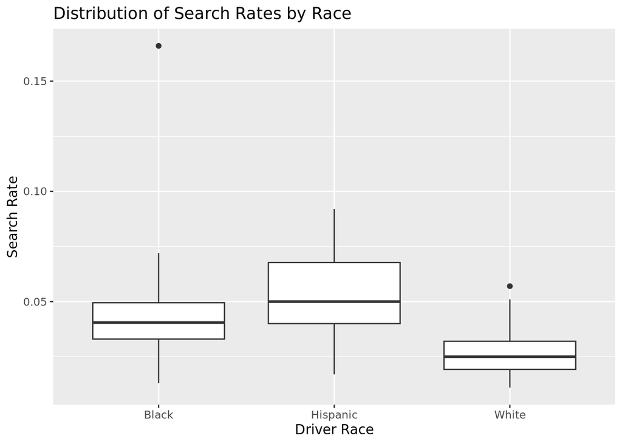

```r
    ggplot(open_policing_ca_data, aes(x=driver_race, y=search_rate)) +
      geom_boxplot(na.rm=TRUE) +
      labs(
          title = "Distribution of Search Rates by Race",
          x = "Driver Race",
          y = "Search Rate"
      )
```

The boxplot above shows that white drivers tend to have the lowest variation in search rates across California counties, and tend to have the lowest median search rate between White, Black, and Hispanic drivers. On the other hand, Hispanic drivers tend to have the highest variation in search rates across California counties, and tend to have the highest median search rate out of White, Black, and Hispanic drivers. I notice on the graph that there is an outlier in the search rate of Black drivers in one California county. This county seems to have a much higher search rate of Black drivers, and might be worth investigating in my deeper analysis.

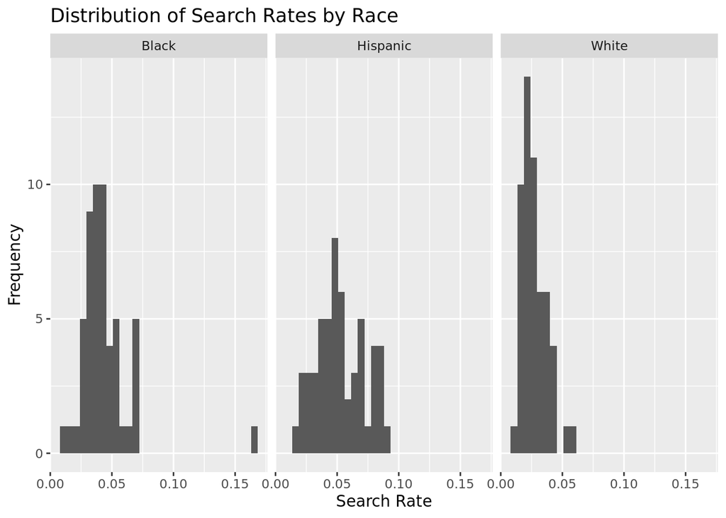

```r
    ggplot(open_policing_ca_data, aes(x=search_rate)) +
      geom_histogram(bins = 30) +
      facet_wrap(~ driver_race) +
      labs(
          title = "Distribution of Search Rates by Race",
          x = "Search Rate",
          y = "Frequency"
      )
```

The histogram above shows the distribution of search rates by race. Hispanic drivers appear to have a greater portion of higher search rates and have the most spread, while White drivers appear to have the lowest spread. This matches with the boxplot from before. However, in the histogram, it appears that all 3 racial groups have plots that are skewed right, which suggests that most counties in California have low search rates across groups.

D. Proposed methods:

I plan to use linear regression to model the association between stop rate and search rate, faceted by driver race. Stop rate and search rate are continuous, numerical variables which allow me to use a linear regression model. A positive slope would tell me that there is a positive correlation between these variables, while a negative slope would tell me that there is a negative correlation between these variables. A positive correlation would indicate that a higher stop rate is associated with a higher search rate. I also plan to use visualizations such as scatter plots and histograms to show these relationships across counties. I also plan to sort California counties into cultural regions (Northern California, Southern California) and investigate if Simpson’s paradox applies.

E. Hypothesized results:

My hypothesis is that Black and Hispanic drivers have higher search rates than White drivers, across Northern and Southern California, and California as a whole. I expect that Black and Hispanic drivers will have a more positive association between their stop rates and search rates than White drivers because of potential implicit racial bias.

Coefficients in the linear regression model would help me identify this as well as lines of best fits in my scatter plots. More specifically, a greater slope would indicate a more positive association, and a smaller slope would indicate a more negative/less positive association.